# Project 3

Kenan Sooklall

3/23/2021

Read in the job listings

```r
jdf <- read.csv(paste0(path, 'ds_job_listing_software.csv'))
jdf <- jdf[1:37,]
jdf <- jdf %>% select(c(Keyword, LinkedIn, Indeed, SimplyHired, Monster)) %>% rename('skill'='Keyword')
jdf[,2:5] <- lapply(jdf[,2:5],function(x){as.numeric(gsub(",", "", x))})
jdf <- jdf %>% mutate(total = rowSums(across(where(is.numeric))))
glimpse(jdf)
```

```
## Rows: 37
## Columns: 6
## $ skill       <chr> "Python", "R", "SQL", "Spark", "Hadoop", "Java", "SAS", "T…
## $ LinkedIn    <dbl> 6347, 4553, 3879, 2169, 2142, 1944, 1713, 1216, 1182, 1040…
## $ Indeed      <dbl> 3818, 3106, 2628, 1551, 1578, 1377, 1134, 1012, 830, 739, …
## $ SimplyHired <dbl> 2888, 2393, 2056, 1167, 1164, 1059, 910, 780, 637, 589, 58…
## $ Monster     <dbl> 2544, 2365, 1841, 1062, 1200, 1002, 978, 744, 619, 520, 43…
## $ total       <dbl> 15597, 12417, 10404, 5949, 6084, 5382, 4735, 3752, 3268, 2…
```

Create a stuff(i need a name for this column) feature based on the skills

```r
## Map skills and then plot
frameworks <- c('TensorFlow', 'Scikit-learn', 'Pandas', 'Numpy', 'Keras', 'PyTorch', 'Caffe')
languages <- c('Python', 'R', 'Java', 'C', 'Scala', 'C++', 'Matlab', 'C# ', 'Javascript', 'SPSS', 'Perl')
database <- c('SQL', 'Hadoop', 'Spark', 'SAS', 'Tableau', 'Hive', 'AWS', 'NoSQL', 'Azure', 'Pig', 'Hbase', 'Cassandra', 'MySQL', 'MongoDB', 'D3')
other <- c('SPSS', 'Excel', 'Linux', 'Docker', 'Git')

jdf <- jdf %>% mutate(stuff=case_when(group=jdf$skill %in% frameworks ~ 'Framework', jdf$skill %in% languages ~ 'Languages', jdf$skill %in% database ~ 'Database', jdf$skill %in% other ~ 'Other'))
glimpse(jdf)
```

```
## Rows: 37
## Columns: 7
## $ skill       <chr> "Python", "R", "SQL", "Spark", "Hadoop", "Java", "SAS", "T…
## $ LinkedIn    <dbl> 6347, 4553, 3879, 2169, 2142, 1944, 1713, 1216, 1182, 1040…
## $ Indeed      <dbl> 3818, 3106, 2628, 1551, 1578, 1377, 1134, 1012, 830, 739, …
## $ SimplyHired <dbl> 2888, 2393, 2056, 1167, 1164, 1059, 910, 780, 637, 589, 58…
## $ Monster     <dbl> 2544, 2365, 1841, 1062, 1200, 1002, 978, 744, 619, 520, 43…
## $ total       <dbl> 15597, 12417, 10404, 5949, 6084, 5382, 4735, 3752, 3268, 2…
## $ stuff       <chr> "Languages", "Languages", "Database", "Database", "Databas…
```

How valuable are each stuff on different hiring websites?

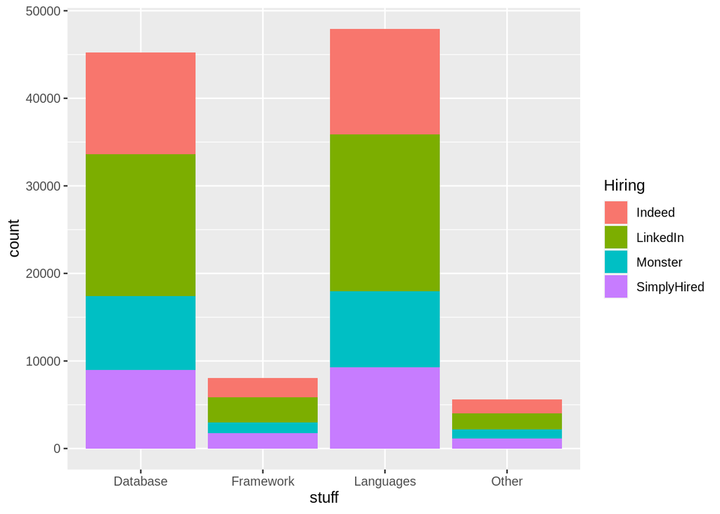

```r
jdf %>% select(!c('skill', 'total')) %>% pivot_longer(!c(stuff), names_to='Hiring', values_to='count') %>% ggplot(aes(x=stuff, y=count, fill=Hiring)) + geom_col()
```

Having experience in a specific language and knowledge of databases is more important than knowing a specific frame work. This makes sense since frame works get updated a lot as things change.

What languages are the most in demand?

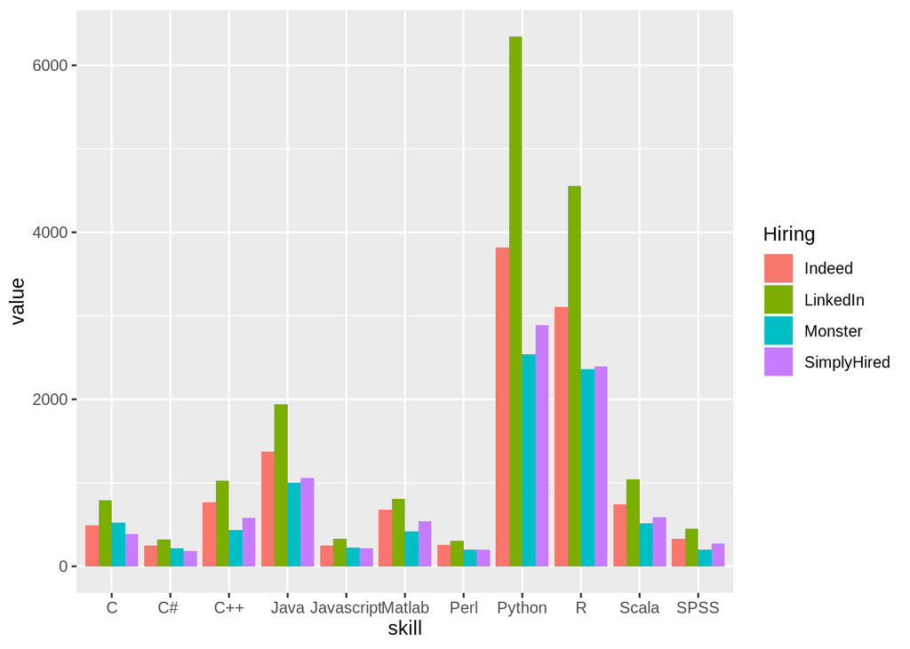

```r
jdf %>% select(!c('total' ,'stuff')) %>%  pivot_longer(!c(skill), names_to='Hiring', values_to='value') %>% filter(skill %in% languages) %>% ggplot(aes(x=skill, y=value, fill=Hiring, group=Hiring)) + geom_bar(stat='identity', position='dodge')
```

It’s very clear that knowledge of python and R are very important if one wants a successful carrier in data science.

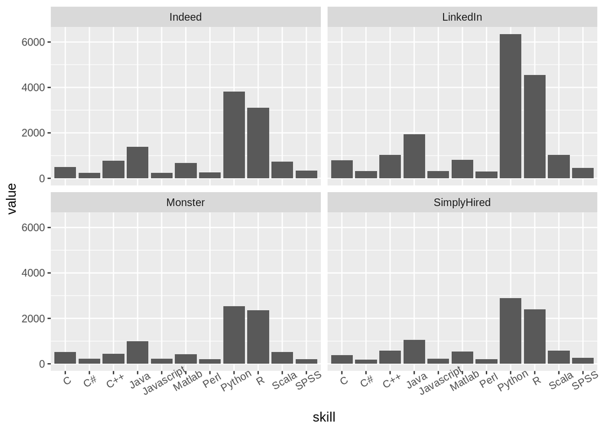

```r
jdf %>% select(!c('total' ,'stuff')) %>%  pivot_longer(!c(skill), names_to='Hiring', values_to='value') %>% filter(skill %in% languages) %>% ggplot(aes(x=skill, y=value)) + geom_col() + facet_wrap(~Hiring) + theme(axis.text.x = element_text(angle = 30))
```

Looking at fulltime positions in NY

```r
ndf <- read.csv(paste0(path, 'fulltimeNY.csv'))

ds <- c('Staff Data Scientist', 'Machine Learning Data Scientist', 'Junior Data Scientist', 'Data Scientist,Analytics', 'Data Scientist (NYC)', 'Clinical Data Scientist')
sds <- c('Sr. Data Scientist', 'Sr Data Scientist', 'Senior Data Scientist', 'Senior Associate, Data Scientist')
lds <- c('Lead Data Scientist')
pds <- c('Principal Data Scientist')

analyst <- ndf %>% filter(across(position, ~grepl('analyst', ignore.case=T, .))) %>% pull(position)
machine_learning <- ndf %>% filter(across(position, ~grepl('machine learning', ignore.case=T, .))) %>% pull(position)
manager <- ndf %>% filter(across(position, ~grepl('manager', ignore.case=T, .))) %>% pull(position)

ndf <- ndf %>% mutate(emp=case_when(group=ndf$position %in% analyst ~ 'Analyst', ndf$position %in% machine_learning ~ 'Machine_learning', ndf$position %in% manager ~ 'Manager'))
ndf$emp <- ndf$emp %>% replace_na('Data Scientist')
glimpse(ndf)
```

```
## Rows: 986
## Columns: 6
## $ position    <chr> "Data Scientist—Research (Ref # EXEC/RD_DAT_NYC_6073)", "D…
## $ company     <chr> "New York State Office of the Attorney General (OAG)", "Ce…
## $ description <chr> "<span id=\"job_summary\" class=\"summary\"><p><b>Executiv…
## $ numreview   <chr> "", "", "217 reviews", "", "", "", "7 reviews", "705 revie…
## $ location    <chr> "New York, NY", "New York, NY", "New York, NY 10032", "Jer…
## $ emp         <chr> "Data Scientist", "Data Scientist", "Analyst", "Data Scien…
```

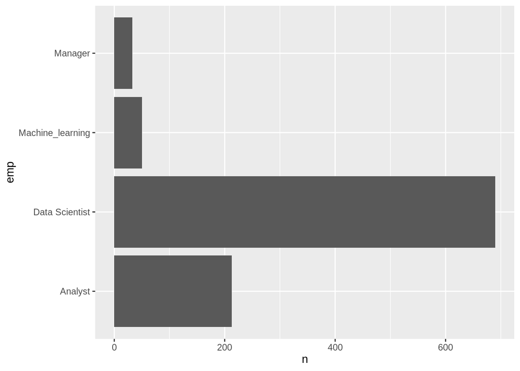

```r
ndf %>% count(emp) %>% top_n(n=20) %>% ggplot(aes(x=emp, y=n)) + geom_col() + coord_flip()
```

Right now there is a lot of demand for Data Scientists vs Managers and Analyst; however there is a lot of overlap. One can assume a manager was once a data scientist that got promoted.

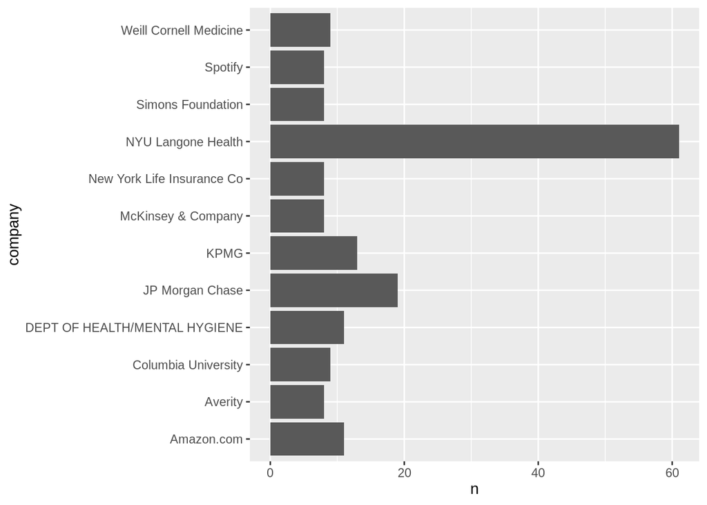

```r
ndf %>% filter(emp == 'Data Scientist') %>% count(company) %>% top_n(n=10) %>% ggplot(aes(x=company, y=n)) + geom_col() + coord_flip()
```

Word cloud of description by position

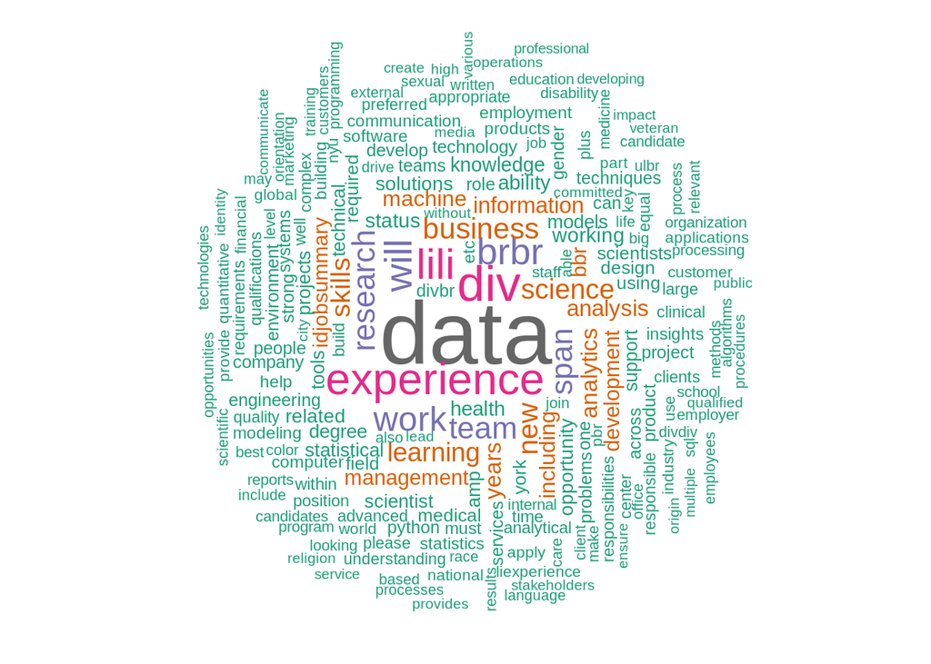

```r
ddf <- ndf %>% filter(emp == 'Data Scientist')

docs <- Corpus(VectorSource(ddf$description))

toSpace <- content_transformer(function (x , pattern ) gsub(pattern, " ", x))
docs <- tm_map(docs, toSpace, "/")
docs <- tm_map(docs, toSpace, "@")
docs <- tm_map(docs, toSpace, "\\|")

# Convert the text to lower case
docs <- tm_map(docs, content_transformer(tolower))
# Remove numbers
docs <- tm_map(docs, removeNumbers)
# Remove english common stopwords
docs <- tm_map(docs, removeWords, stopwords("english"))
# Remove your own stop word
# specify your stopwords as a character vector
docs <- tm_map(docs, removeWords, c("blabla1", "blabla2"))
# Remove punctuations
docs <- tm_map(docs, removePunctuation)
# Eliminate extra white spaces
docs <- tm_map(docs, stripWhitespace)

dtm <- TermDocumentMatrix(docs)
m <- as.matrix(dtm)
v <- sort(rowSums(m),decreasing=TRUE)
d <- data.frame(word = names(v),freq=v)

set.seed(1234)
wordcloud(words = d$word, freq = d$freq, min.freq = 200,
          max.words=200, random.order=FALSE, rot.per=0.35,
          colors=brewer.pal(8, "Dark2"))
```

As one would expect data scientist need to have a very good understanding of data in every aspect. From analytics, statistics, management and everything in between. The word cloud also emphases the need for team work, machine learning and a lot of experience.